# Лабораторная работа № 1

Установка ОС Linux

Мальянц В. К.

Российский университет дружбы народов, Москва, Россия

02 марта 2025

## Цель работы

- Приобретение практических навыков установки операционной системы на виртуальную машину, настройки минимально необходимых для дальнейшей работы сервисов.

## Задание

- Установка Linux на Virtualbox
- Установка операционной системы
- Установка драйверов для VirtualBox
- Подключение общей папки
- Обновления
- Повышение комфорта работы
- Автоматическое обновление
- Отключение SELINUX
- Настройка раскладки клавиатуры
- Установка программного обеспечения для создания документации
- Отчет о выполнении дополнительного задания

# Выполнение лабораторной работы

## Установка Linux на Virtualbox

- Создаю новую виртуальную машину. Задаю ей имя и образ ISO (рис. 1).

[figure not shown]

Имя и ISO

## Установка Linux на Virtualbox

- Выделяю оперативную память размеров 4096 мб (рис. 2).

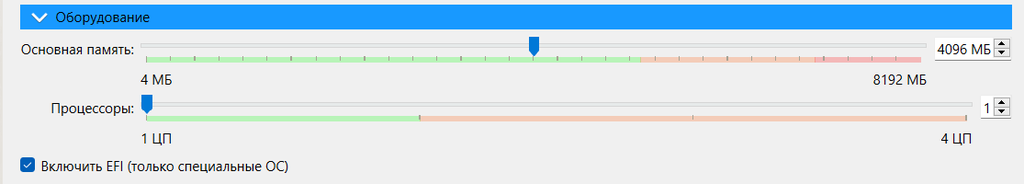

Оперативная память

## Установка Linux на Virtualbox

- Создаю новый виртуальный жесткий диск размером 80 гб (рис. 3).

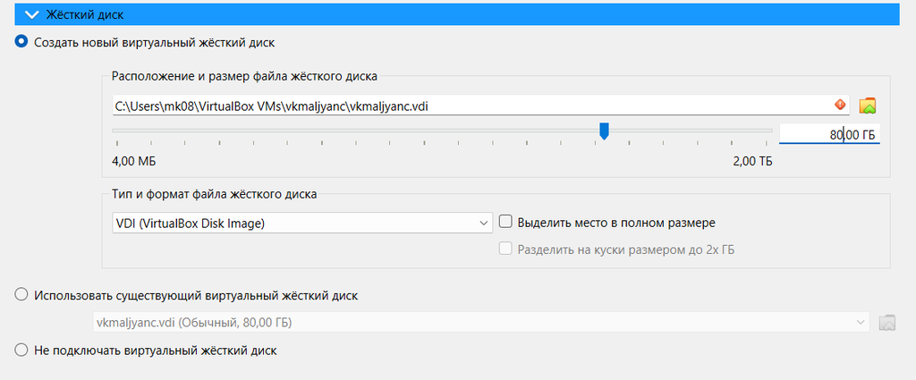

Новый виртуальный жесткий диск

## Установка Linux на Virtualbox

- Запускаю виртуальную машину(рис. 4).

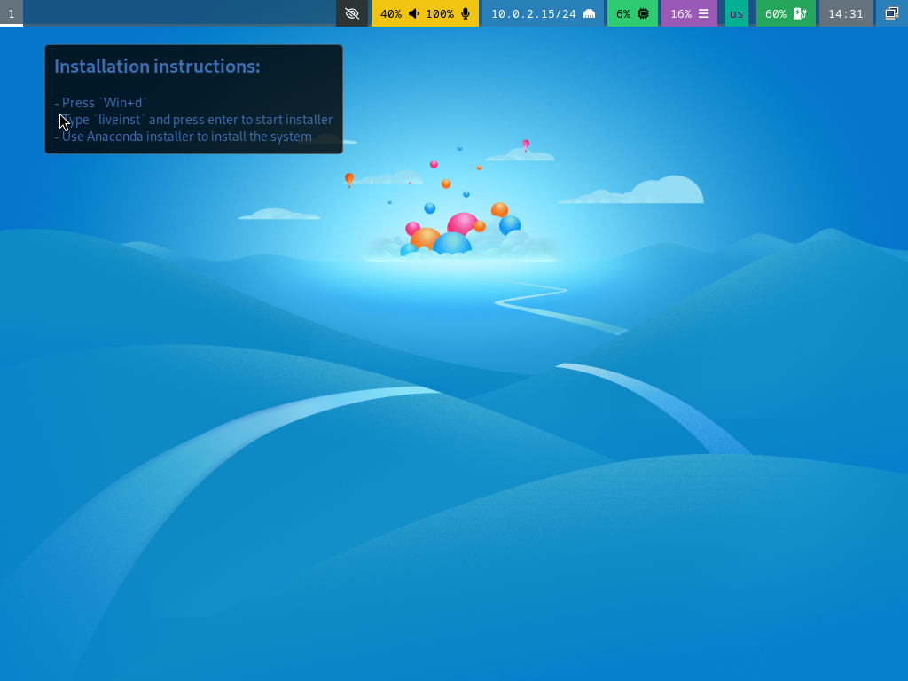

Запуск виртуальной машины

## Установка операционной системы

- Запускаю терминальный мультиплексор tmux (рис. 5).

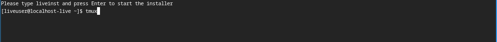

Запуск терминального мультиплексора tmux

## Установка операционной системы

- В терминале запускаю liveinst (рис. 6).

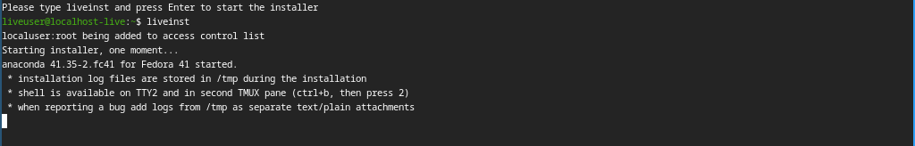

запуск liveinst

## Установка операционной системы

- Выбираю язык (рис. 7).

[figure not shown]

Выбор языка

## Установка операционной системы

- Настраиваю раскладку клавиатуры (рис. 8).

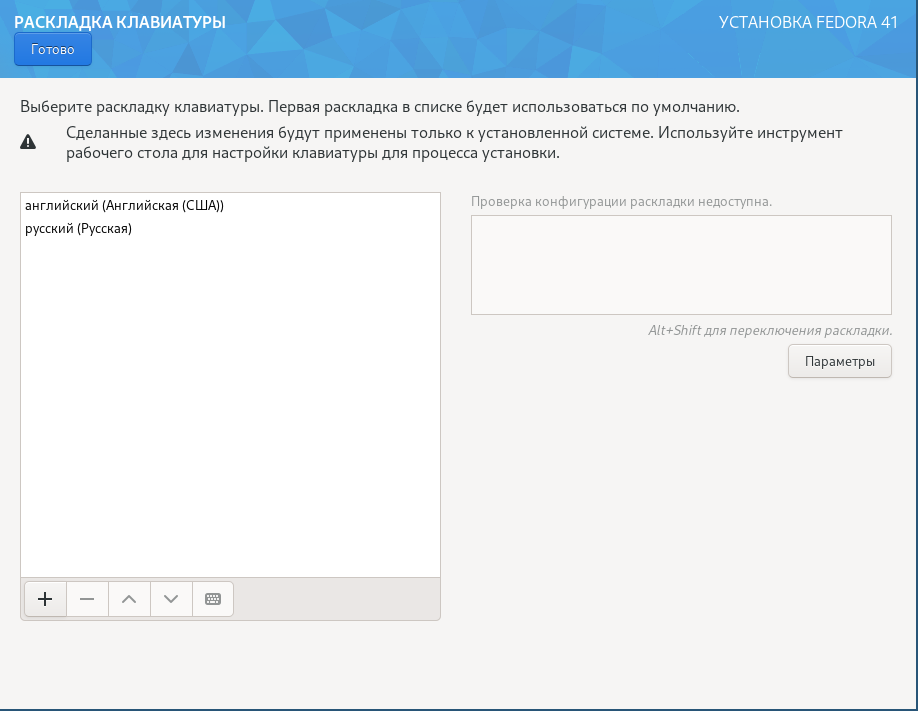

Настройка раскладки клавиатуры

## Установка операционной системы

- Выбираю часовой пояс (рис. 9).

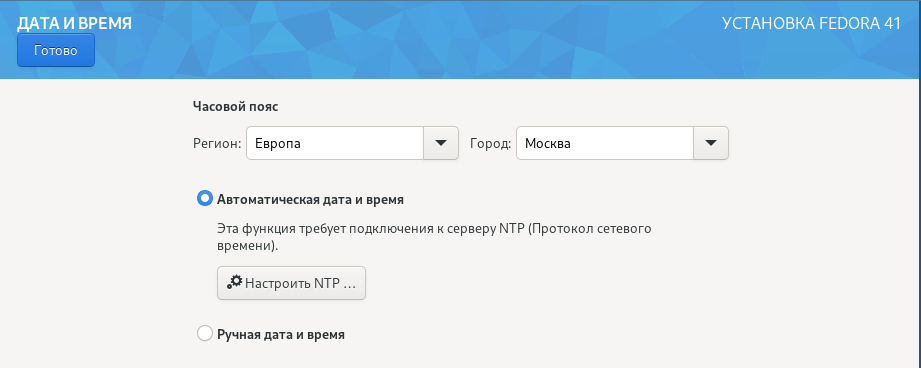

Выбор часового пояса

## Установка операционной системы

- Выбираю место установки (рис. 10).

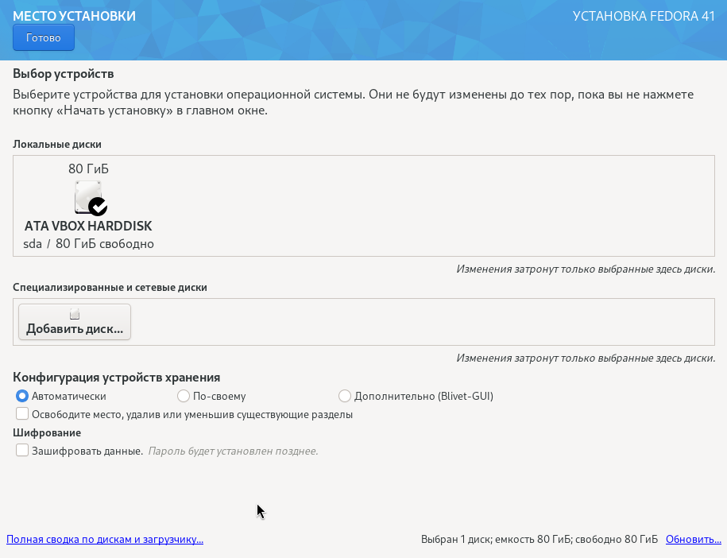

Выбор места установки

## Установка операционной системы

- Выбираю имя узла (рис. 11).

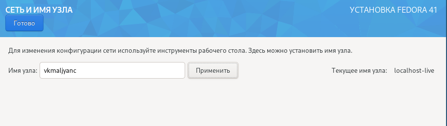

Выбор имени узла

## Установка операционной системы

- Включаю учетную запись root (рис. 12).

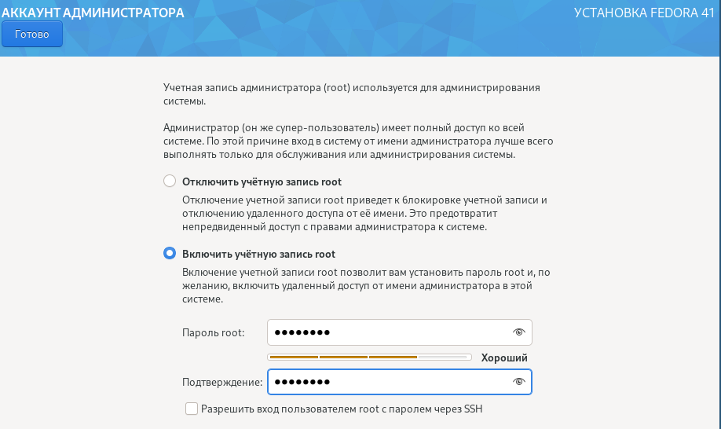

Включение учетной запись root

## Установка операционной системы

- Устанавливаю имя и пароль для пользователя (рис. 13).

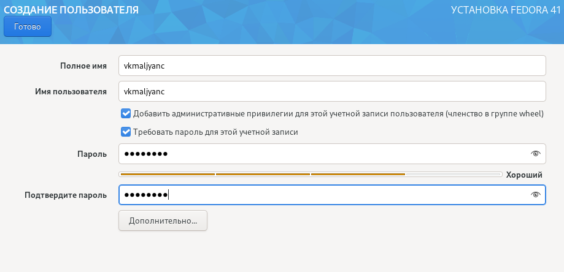

Установка имени и пароля для пользователя

## Установка операционной системы

- Убеждаюсь в правильности выбора настроек (рис. 14).

[figure not shown]

Обзор установки

- Ход установки (рис. 15).

[figure not shown]

Ход установки

- Отключаю оптический диск (рис. 16).

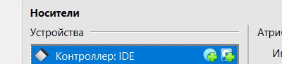

Отключение оптического диска

## Установка драйверов для VirtualBox

- Вхожу в ОС под заданной при установке учетной записью (рис. 17).

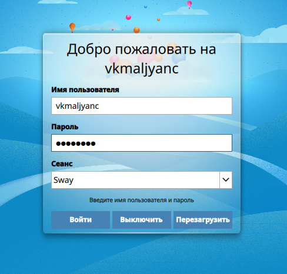

Вход в ОС

## Установка операционной системы

- Переключаюсь на роль супер-пользователя с помощью sudo-i и устанавливаю средства разработки(рис. 18).

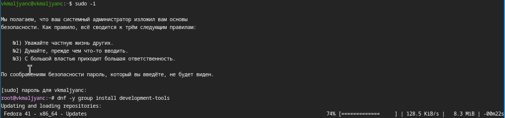

Переключение на роль супер-пользователя и установка средств разработки

## Установка операционной системы

- Устанавливаю пакет DKMS (рис. 19).

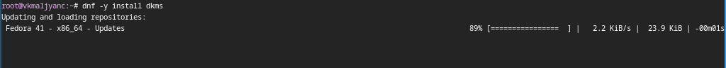

Установка пакета DKMS

## Установка операционной системы

- Перезагружаю виртуальную машину с помощью reboot(рис. 20).

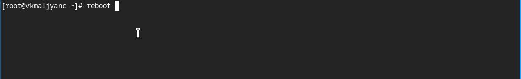

Перезагрузка виртуальной машины

## Установка операционной системы

- В меню виртуальной машины подключаю образ диска дополнений гостевой ОС (рис. 21).

[figure not shown]

Подключение образа диска дополнений гостевой ОС

## Установка операционной системы

- Монтирую диск с помощью mount (рис. 22).

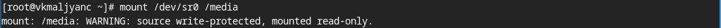

Монтирование диска

## Установка операционной системы

- Устанавливаю драйвера (рис. 23).

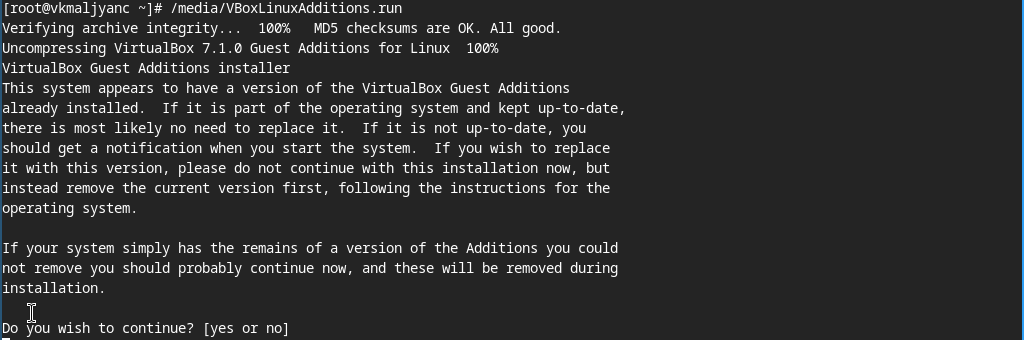

Установка драйверов

## Обновления

- Переключаюсь на роль супер-пользователя с помощью sudo-i (рис. 28).

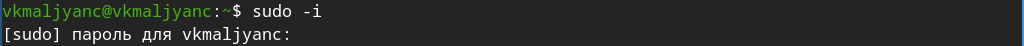

Переключение на роль супер-пользователя с помощью sudo-i

## Обновления

- Обновляю все пакеты (рис. 29).

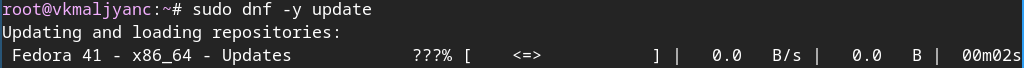

Обновление всех пакетов

## Повышение комфорта работы

- Устанавливаю программу для удобства работы в консоли (рис. 30).

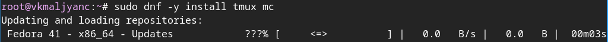

Установка программы для удобства работы в консоли

## Повышение комфорта работы

- Устанавливаю другой вариант консоли (рис. 31).

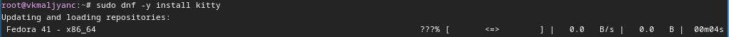

Установка другого варианта консоли

## Автоматическое обновление

- Устанавливаю программное обеспечение для автоматического обновления (рис. 32).

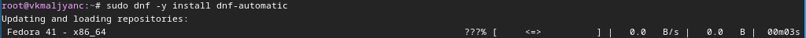

Установка программного обеспечения для автоматического обновления

## Отключение SELINUX

- Переключаюсь на роль супер-пользователя с помощью sudo-i и перехожу в каталог selinux (рис. 34).

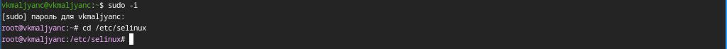

Переключение на роль супер-пользователя с помощью sudo-i и переход в каталог selinux

## Отключение SELINUX

- Изменяю значение SELINUX c enforcing на permissive (рис. 36).

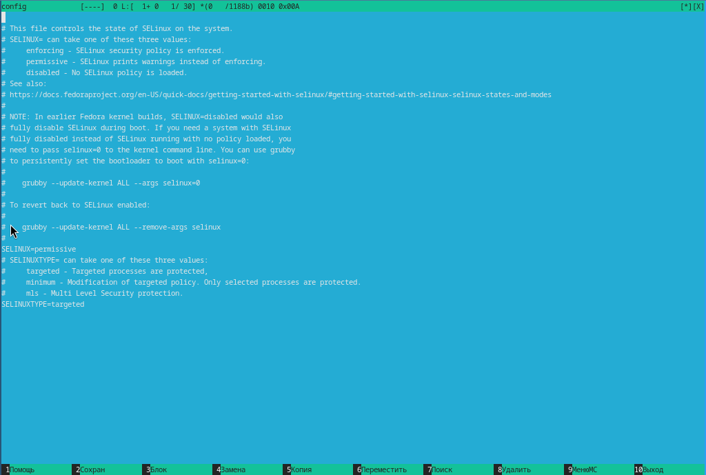

Изменение значения SELINUX c enforcing на permissive